# Gaze Following SRCD Analysis

The Gaze Following Analysis Team

Sat Mar 16 22:20:31 2019

# 1 Intro

*copied from 04_confirmatory_analysis.Rmd*

This RMarkdown file reports analyses of the primary Gaze Following dataset. It relies on data cached in `03_exclusions.Rmd`.

There are four datasets for MLM models

- d_first: direction of first look (congruent/incongruent) and latency of first shifts. Proportion difference score (c-i)/(c+i)
- d_freq: frequency of looks to congruent vs. incongruent. Proportion difference score (c-i)/(c+i)
- d_duration: fixation duration to congruent vs. incongruent. Proportion difference score (c-i)/(c+i)
- d_latency: infants’ reaction time

And their associated datasets for meta-analysis

- d_first_meta: direction of first look (congruent/incongruent) and latency of first shifts. Proportion difference score (c-i)/(c+i)
- d_freq_meta: frequency of looks to congruent vs. incongruent. Proportion difference score (c-i)/(c+i)
- d_duration_meta: fixation duration to congruent vs. incongruent. Proportion difference score (c-i)/(c+i)
- d_latency_meta: infants’ reaction time

```r
iv_columns <- c("lab", "subid", "trial_num", "age_group", "age_days", "participant_gender", "lang_group", "coding")
dv_columns <- c("first_shift", "latency", "n_shift_congruent", "n_shift_incongruent", "fixation_congruent", "fixation_incongruent")

d <- read_csv("processed_data/03_data_trial_main.csv") %>%
  select(iv_columns, dv_columns) %>%
  mutate_at(vars(lab,subid,age_group, participant_gender, lang_group, first_shift, coding), as.factor) %>%
  mutate_at(vars(age_group, lang_group), fct_rev)

#clean-up
rm(iv_columns, dv_columns)
```

# 2 Filter dataset

The SRCD analysis will include only eye-tracking data, as hand-coded data is still being processed and verified.

```r
d <- d %>% filter(coding == "gazepath")
```

## 2.1 First look

*The proportion of first-shifts to congruent versus incongruent trials by infant* For this data we look only at the infants first gaze shifts, and examine the proportion of congruent first gaze-shifts across infants.

```r
d_first <- d %>%
  filter(!is.na(first_shift)) %>% # Select only trials that had a shift
  select(-latency, -n_shift_congruent, -n_shift_incongruent, -fixation_congruent,
         -fixation_incongruent)

d_first_meta <- d_first %>%
  group_by_at(vars(-trial_num)) %>%
  summarise(n = n()) %>%
  spread(key = first_shift, value = n, fill = 0) %>%
  mutate(prop = (congruent-incongruent)/(congruent+incongruent)) %>% # Calculate proportion difference score
  select(-congruent, -incongruent) %>%
  filter(!is.na(prop)) %>%
  group_by(subid, age_group, lang_group, lab) %>%
  summarise(prop = mean(prop, na.rm = TRUE))
```

## 2.2 Let’s start with First-looks

# 3 Pirate plot

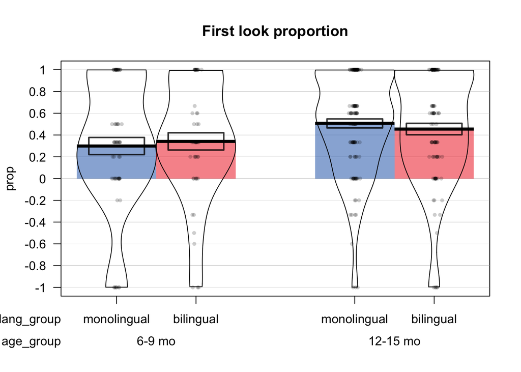

```r
d_first_meta %>%
  group_by(subid, age_group, lang_group) %>%
  summarise(prop = mean(prop, na.rm = TRUE)) %>%
  pirateplot(formula = prop ~ lang_group + age_group, data = ., main = "First look proportion", theme = 1, bar.f.o = .5, bean.f.o = 0, bar.b.col = 1, bar.lwd = .5, bean.b.col = 1, inf.f.o = 0, inf.method = "se")
```

Same-ish thing but with ggplot:

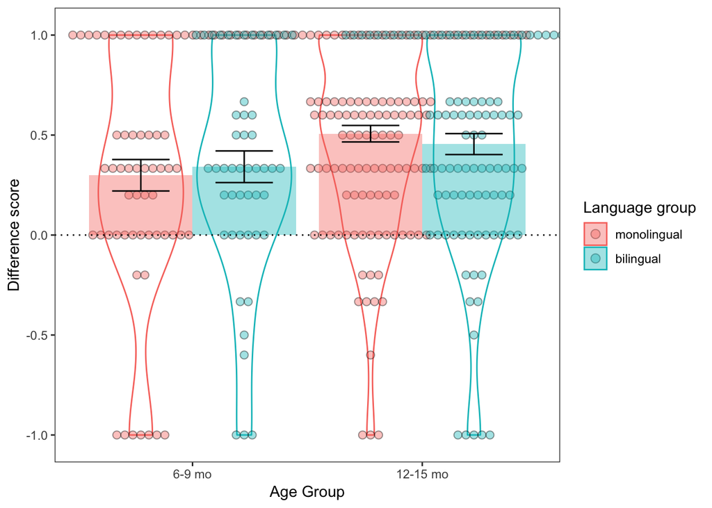

```r
d_first_meta %>%
  group_by(subid, age_group, lang_group) %>%
  summarise(prop = mean(prop, na.rm = TRUE)) %>%
  ggplot(aes(x = age_group, y = prop)) +
  geom_violin(aes(colour = lang_group)) +
  geom_dotplot(binaxis = "y", stackdir = "center", position = position_dodge(width = 0.9),
               dotsize = .6, alpha = 0.4, aes(fill = lang_group)) +
  stat_summary(fun.y = "mean", geom = "bar", aes(fill = lang_group),
               alpha = .4, position = position_dodge(width = 0.9)) +
  stat_summary(fun.data = mean_se, geom = "errorbar", width = .5, aes(group = lang_group),
               position = position_dodge(width = 0.9)) +
  geom_abline(intercept = 0, lty = 3, slope = 0) +
  ylab("Difference score") +
  xlab("Age Group") +
  guides(colour = guide_legend(title = "Language group"),
         fill = guide_legend(title = "Language group"))
```

These plots tell us that across the entire sample, infants first looks were more likely to be to the congruent as opposed to the incongruent. It also looks as though older infants have a greater proportion first-congruent-look. Little obvious evidence for a difference between language groups.

## 3.1 First_look MLM

```r
first_glmer <- d_first %>%
  mutate(age_days = scale(age_days, scale = FALSE)) %>%
  filter(!is.na(first_shift)) %>%
  mutate(first_shift = fct_rev(first_shift)) %>% # So higher numbers mean more looks to congruent
  glmer(first_shift ~ lang_group + age_days + (1|subid) + (1|lab) + (1|trial_num),
  data = .,
  family = binomial
)

summary(first_glmer)
```

```
## Generalized linear mixed model fit by maximum likelihood (Laplace
##   Approximation) [glmerMod]
##  Family: binomial  ( logit )
## Formula: first_shift ~ lang_group + age_days + (1 | subid) + (1 | lab) +
##     (1 | trial_num)
##    Data: .
##
##      AIC      BIC   logLik deviance df.resid
##   1595.9   1627.2   -791.9   1583.9     1358
##
## Scaled residuals:
##     Min      1Q  Median      3Q     Max
## -1.9356 -1.4356  0.5742  0.6052  0.7554
##
## Random effects:
##  Groups    Name        Variance  Std.Dev.
##  subid     (Intercept) 1.312e-10 1.146e-05
##  lab       (Intercept) 1.045e-02 1.022e-01
##  trial_num (Intercept) 5.684e-04 2.384e-02
## Number of obs: 1364, groups:  subid, 339; lab, 9; trial_num, 6
##
## Fixed effects:
##                       Estimate Std. Error z value Pr(>|z|)
## (Intercept)          1.0352947  0.0923244  11.214   <2e-16 ***
## lang_groupbilingual -0.0682130  0.1244723  -0.548   0.5837
## age_days             0.0019452  0.0008003   2.431   0.0151 *
## ---
## Signif. codes:  0 '***' 0.001 '**' 0.01 '*' 0.05 '.' 0.1 ' ' 1
##
## Correlation of Fixed Effects:
##             (Intr) lng_gr
## lng_grpblng -0.615
## age_days     0.001  0.079
## convergence code: 0
## singular fit
```

```r
#Tried simplifying this model iteratively; continue to get singular fit
```

## 3.2 Meta-analysis

```r
d_z_first <- d_first_meta %>%
  group_by(subid, lab, age_group, lang_group) %>%
  summarise(mean_prop = mean(prop, na.rm = TRUE)) %>%
  group_by(lab, age_group, lang_group) %>%
  summarise(d = mean(mean_prop, na.rm = TRUE) / sd(mean_prop, na.rm = TRUE),
            n = length(unique(subid)),
            d_var = d_var_calc(n, d)) %>%
 filter(n >= 10) #Filtering out subgroups with fewer than 10 babies
```

## 3.3 First look model with language and age

```r
first_meta <- metafor::rma(d ~ lang_group * age_group, vi = d_var,
                    slab = lab, data = d_z_first, method = "REML")
summary(first_meta)
```

```
##
## Mixed-Effects Model (k = 17; tau^2 estimator: REML)
##
##   logLik  deviance       AIC       BIC      AICc
##  -9.4475   18.8949   28.8949   31.7197   37.4664
##
## tau^2 (estimated amount of residual heterogeneity):     0.0537 (SE = 0.0770)
## tau (square root of estimated tau^2 value):             0.2317
## I^2 (residual heterogeneity / unaccounted variability): 27.22%
## H^2 (unaccounted variability / sampling variability):   1.37
## R^2 (amount of heterogeneity accounted for):            37.71%
##
## Test for Residual Heterogeneity:
## QE(df = 13) = 20.2899, p-val = 0.0882
##
## Test of Moderators (coefficient(s) 2:4):
## QM(df = 3) = 6.2396, p-val = 0.1005
##
## Model Results:
##
##                                        estimate      se     zval    pval
## intrcpt                                  0.5386  0.2541   2.1195  0.0340
## lang_groupbilingual                     -0.0282  0.4069  -0.0694  0.9447
## age_group12-15 mo                        0.6302  0.3053   2.0640  0.0390
## lang_groupbilingual:age_group12-15 mo   -0.1383  0.4830  -0.2863  0.7746
##                                          ci.lb   ci.ub
## intrcpt                                 0.0405  1.0366  *
## lang_groupbilingual                    -0.8258  0.7693
## age_group12-15 mo                       0.0318  1.2285  *
## lang_groupbilingual:age_group12-15 mo  -1.0850  0.8084
##
## ---
## Signif. codes:  0 '***' 0.001 '**' 0.01 '*' 0.05 '.' 0.1 ' ' 1
```

Ignoring the singular fit of the MLM, both meta and MLM tell us the same story: Older infants had a higher proportion of congruent first-looks, but there was no effect of language group (and no interaction). The meta furthermore suggest that the total sum of moderators is not significant (i.e. some moderators could be pruned). [I think this can be interpreted this way]

# 4 Frequency of congruent gaze shifts

```r
d_freq <- d %>%
  select(-first_shift, -latency, -fixation_congruent, - fixation_incongruent) %>%
  filter((n_shift_congruent + n_shift_incongruent) > 0) %>% # Select only trials that had a shift
  gather(key = "object", value = "n_shift", n_shift_congruent, n_shift_incongruent) %>%
  mutate(object = case_when(
    object == "n_shift_congruent" ~ "congruent",
    object == "n_shift_incongruent" ~ "incongruent"
  )) %>%
  mutate(object = as.factor(object))

d_freq_meta <- d  %>%
  group_by_at(vars(-trial_num)) %>%
  select(-first_shift, -latency, -fixation_congruent, - fixation_incongruent) %>%
  filter((n_shift_congruent + n_shift_incongruent) > 0) %>% # Select only trials that had a shift
  mutate(prop = (n_shift_congruent -  n_shift_incongruent)/(n_shift_congruent + n_shift_incongruent)) %>% # Calculate proportion difference score on each trial
  group_by_at(vars(-trial_num, - prop)) %>%
  mutate(prop = mean(prop)) %>% # Average proportion difference score by baby
  group_by(subid, age_group, lang_group, lab) %>%
  summarise(prop = mean(prop, na.rm = TRUE))
```

## 4.1 Visualization

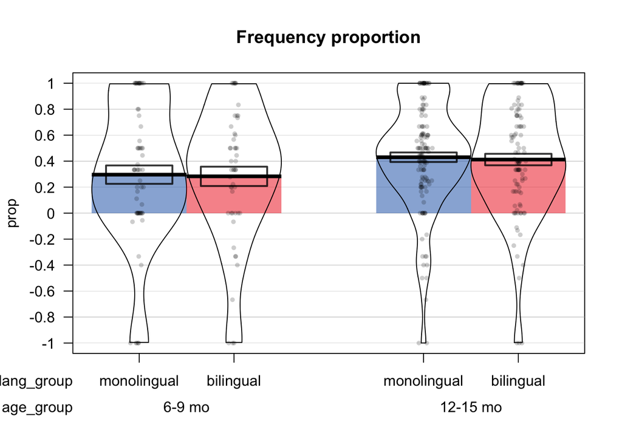

```r
pirateplot(formula = prop ~ lang_group + age_group, data = d_freq_meta, main = "Frequency proportion", theme = 1, bar.f.o = .5, bean.f.o = 0, bar.b.col = 1, bar.lwd = .5, bean.b.col = 1, inf.f.o = 0, inf.method = "se")
```

## 4.2 Frequency LMEM

```r
#freq_lmer <- d_freq %>%
#  mutate(age_days = scale(age_days, scale = FALSE)) %>%
#  mutate(object_bin = (as.integer(fct_rev(object)) - 1)) %>% # Recode to binary: congruent = 1, #incongruent = 0
#  lmer(n_shift ~ lang_group*age_days*object + (object|subid) + (lang_group*object|lab) + #(lang_group*object|trial_num),
#  data = .
#)

freq_lmer <- d_freq %>%
  mutate(age_days = scale(age_days, scale = FALSE)) %>%
  mutate(object_bin = (as.integer(fct_rev(object)) - 1)) %>% # Recode to binary: congruent = 1, incongruent = 0
  lmer(n_shift ~ object + (1|subid),
  data = .
)

summary(freq_lmer)
```

```
## Linear mixed model fit by REML. t-tests use Satterthwaite's method [
## lmerModLmerTest]
## Formula: n_shift ~ object + (1 | subid)
##    Data: .
##
## REML criterion at convergence: 6169.6
##
## Scaled residuals:
##     Min      1Q  Median      3Q     Max
## -1.6161 -0.6824 -0.2689  0.6543  5.0735
##
## Random effects:
##  Groups   Name        Variance  Std.Dev.
##  subid    (Intercept) 0.0003312 0.0182
##  Residual             0.5596077 0.7481
## Number of obs: 2728, groups:  subid, 339
##
## Fixed effects:
##                     Estimate Std. Error         df t value Pr(>|t|)
## (Intercept)          1.20146    0.02028 1158.08207   59.23   <2e-16 ***
## objectincongruent   -0.69062    0.02865 2484.92693  -24.11   <2e-16 ***
## ---
## Signif. codes:  0 '***' 0.001 '**' 0.01 '*' 0.05 '.' 0.1 ' ' 1
##
## Correlation of Fixed Effects:
##             (Intr)
## objctncngrn -0.706
```

Singular fit, again. Model reduction to avoid this error leads to the simple model above, of object and random intercepts for subjects (or trial number).

## 4.3 Meta-analysis

```r
d_z_freq <- d_freq_meta %>%
  group_by(lab, age_group, lang_group) %>%
  summarise(d = mean(prop, na.rm = TRUE) / sd(prop, na.rm = TRUE),
            n = length(unique(subid)),
            d_var = d_var_calc(n, d)) %>%
  filter(n >= 10) #Filtering out subgroups with fewer than 10 babies
```

```r
freq_meta <- metafor::rma(d ~ lang_group * age_group, vi = d_var,
                    slab = lab, data = d_z_freq, method = "REML")
summary(freq_meta)
```

```
##
## Mixed-Effects Model (k = 17; tau^2 estimator: REML)
##
##   logLik  deviance       AIC       BIC      AICc
##  -6.1209   12.2419   22.2419   25.0666   30.8133
##
## tau^2 (estimated amount of residual heterogeneity):     0.0000 (SE = 0.0538)
## tau (square root of estimated tau^2 value):             0.0014
## I^2 (residual heterogeneity / unaccounted variability): 0.00%
## H^2 (unaccounted variability / sampling variability):   1.00
## R^2 (amount of heterogeneity accounted for):            99.99%
##
## Test for Residual Heterogeneity:
## QE(df = 13) = 13.4334, p-val = 0.4149
##
## Test of Moderators (coefficient(s) 2:4):
## QM(df = 3) = 8.2122, p-val = 0.0418
##
## Model Results:
##
##                                        estimate      se     zval    pval
## intrcpt                                  0.5310  0.2151   2.4688  0.0136
## lang_groupbilingual                     -0.1125  0.3454  -0.3258  0.7446
## age_group12-15 mo                        0.5616  0.2569   2.1864  0.0288
## lang_groupbilingual:age_group12-15 mo    0.0015  0.4081   0.0036  0.9971
##                                          ci.lb   ci.ub
## intrcpt                                 0.1094  0.9525  *
## lang_groupbilingual                    -0.7895  0.5645
## age_group12-15 mo                       0.0582  1.0651  *
## lang_groupbilingual:age_group12-15 mo  -0.7984  0.8014
##
## ---
## Signif. codes:  0 '***' 0.001 '**' 0.01 '*' 0.05 '.' 0.1 ' ' 1
```

This model reveals a similar story as before: older infants make more shifts to the congruent stimuli than do younger infants. No effect of language group. However - the moderator coefficient is significant. Heterogeneity is not significant.

# 5 Duration of LT to congruent objects

```r
d_duration <- d %>%
  select(-first_shift, -latency, -n_shift_congruent, -n_shift_incongruent) %>%
  filter(fixation_congruent + fixation_incongruent > 0) %>% # Select only trials that had any looking
  gather(key = "object", value = "duration", fixation_congruent, fixation_incongruent) %>%
  mutate(object = case_when(
    object == "fixation_congruent" ~ "congruent",
    object == "fixation_incongruent" ~ "incongruent"
  )) %>%
  mutate(object = as.factor(object)) %>%
  mutate(duration = log(duration + 1)) # Log-transform duration scores, adding one to deal with zeros

d_duration_meta <- d %>%
  select(-first_shift, -latency, -n_shift_congruent, -n_shift_incongruent) %>%
  filter(fixation_congruent + fixation_incongruent > 0) %>%
  mutate(prop = (fixation_congruent - fixation_incongruent)/(fixation_congruent + fixation_incongruent)) %>% # Calculate proportion difference score
  group_by_at(vars(-trial_num, - prop)) %>%
  mutate(prop = mean(prop)) # Average proportion difference score by baby
```

## 5.1 Visualization

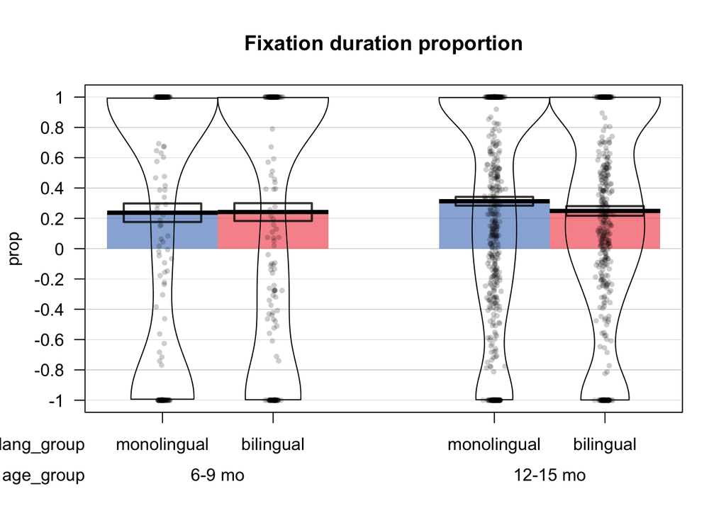

```r
pirateplot(formula = prop ~ lang_group + age_group, data = d_duration_meta, main = "Fixation duration proportion", theme = 1, bar.f.o = .5, bean.f.o = 0, bar.b.col = 1, bar.lwd = .5, bean.b.col = 1, inf.f.o = 0, inf.method = "se")
```

## 5.2 Duration LMEM

```r
duration_lmer <- d_duration %>%
  mutate(age_days = scale(age_days, scale = FALSE)) %>%
  mutate(object_bin = (as.integer(fct_rev(object)) - 1)) %>% # Recode to binary: congruent = 1, incongruent = 0
  lmer(duration ~ lang_group*age_days*object+ (object|subid) + (lang_group*object|lab) + (lang_group*object|trial_num),
  data = .
)

summary(duration_lmer)
```

```
## Linear mixed model fit by REML. t-tests use Satterthwaite's method [
## lmerModLmerTest]
## Formula: duration ~ lang_group * age_days * object + (object | subid) +
##     (lang_group * object | lab) + (lang_group * object | trial_num)
##    Data: .
##
## REML criterion at convergence: 15008.9
##
## Scaled residuals:
##     Min      1Q  Median      3Q     Max
## -2.2324 -1.0390  0.3737  0.6993  1.7471
##
## Random effects:
##  Groups    Name                                  Variance  Std.Dev. Corr
##  subid     (Intercept)                           0.0641742 0.25333
##            objectincongruent                     1.0471326 1.02329  -1.00
##  lab       (Intercept)                           0.0000000 0.00000
##            lang_groupbilingual                   0.0466808 0.21606    NaN
##            objectincongruent                     0.0128908 0.11354    NaN
##            lang_groupbilingual:objectincongruent 0.0766968 0.27694    NaN
##  trial_num (Intercept)                           0.0365100 0.19108
##            lang_groupbilingual                   0.0170001 0.13038   0.64
##            objectincongruent                     0.1365097 0.36947  -0.74
##            lang_groupbilingual:objectincongruent 0.0004815 0.02194  -0.67
##  Residual                                        8.2183507 2.86677
##
##
##
##
##
##  -0.09
##  -0.14 -0.97
##
##
##   0.04
##   0.14  0.99
##
## Number of obs: 3002, groups:  subid, 354; lab, 9; trial_num, 6
##
## Fixed effects:
```

[output cut: 26 more lines]

```
## lang_groupbilingual:age_days:objectincongruent
## ---
## Signif. codes:  0 '***' 0.001 '**' 0.01 '*' 0.05 '.' 0.1 ' ' 1
##
## Correlation of Fixed Effects:
##             (Intr) lng_gr ag_dys objctn lng_:_ lng_g: ag_dy:
## lng_grpblng -0.335
## age_days    -0.030  0.021
## objctncngrn -0.702  0.287  0.014
## lng_grpbl:_  0.020  0.007 -0.657 -0.009
## lng_grpbln:  0.329 -0.570 -0.012 -0.488 -0.012
## ag_dys:bjct  0.016 -0.011 -0.697 -0.013  0.459  0.010
## lng_grpb:_: -0.010 -0.011  0.461  0.010 -0.685  0.024 -0.672
## convergence code: 0
## singular fit
```

## 5.3 Meta-analysis

```r
d_z_dur <- d_duration_meta %>%
  group_by(lab, age_group, lang_group) %>%
  summarise(d = mean(prop, na.rm = TRUE) / sd(prop, na.rm = TRUE),
            n = length(unique(subid)),
            d_var = d_var_calc(n, d)) %>%
  filter(n >= 10) #Filtering out subgroups with fewer than 10 babies
```

```r
dur_meta <- metafor::rma(d ~ lang_group * age_group, vi = d_var,
                    slab = lab, data = d_z_dur, method = "REML")
summary(freq_meta)
```

[output not shown]

```
##
## Mixed-Effects Model (k = 17; tau^2 estimator: REML)
##
##   logLik  deviance       AIC       BIC      AICc
##  -6.1209   12.2419   22.2419   25.0666   30.8133
##
## tau^2 (estimated amount of residual heterogeneity):     0.0000 (SE = 0.0538)
## tau (square root of estimated tau^2 value):             0.0014
## I^2 (residual heterogeneity / unaccounted variability): 0.00%
## H^2 (unaccounted variability / sampling variability):   1.00
## R^2 (amount of heterogeneity accounted for):            99.99%
##
## Test for Residual Heterogeneity:
## QE(df = 13) = 13.4334, p-val = 0.4149
##
## Test of Moderators (coefficient(s) 2:4):
## QM(df = 3) = 8.2122, p-val = 0.0418
##
## Model Results:
##
##                                        estimate      se     zval    pval
## intrcpt                                  0.5310  0.2151   2.4688  0.0136
## lang_groupbilingual                     -0.1125  0.3454  -0.3258  0.7446
## age_group12-15 mo                        0.5616  0.2569   2.1864  0.0288
## lang_groupbilingual:age_group12-15 mo    0.0015  0.4081   0.0036  0.9971
##                                          ci.lb   ci.ub
## intrcpt                                 0.1094  0.9525  *
## lang_groupbilingual                    -0.7895  0.5645
## age_group12-15 mo                       0.0582  1.0651  *
## lang_groupbilingual:age_group12-15 mo  -0.7984  0.8014
##
## ---
## Signif. codes:  0 '***' 0.001 '**' 0.01 '*' 0.05 '.' 0.1 ' ' 1
```

# 6 Latency to congruent first-shifts

```r
d_latency <- d %>%
  select(-n_shift_congruent, -n_shift_incongruent, -fixation_congruent, - fixation_incongruent) %>%
  rename("object" = "first_shift") %>%
  filter(!is.na(object)) %>% # only trials with first shifts
  mutate(latency = log(latency + 1)) # Log transform latency scores, adding one to deal with zeros


d_latency_meta <- d %>%
  select(-n_shift_congruent, -n_shift_incongruent, -fixation_congruent, - fixation_incongruent) %>%
  rename("object" = "first_shift") %>%
  filter(!is.na(object)) %>%
  mutate(object = as.factor(object)) %>%
  group_by_at(vars(-trial_num, - latency)) %>%
  mutate(latency = mean(latency)) # Average proportion difference score by baby
```

## 6.1 Visualization

## 6.2 Latency

```
## [1] "theme must be an integer between 0 and 4. I'll set it to 1 for now."
```

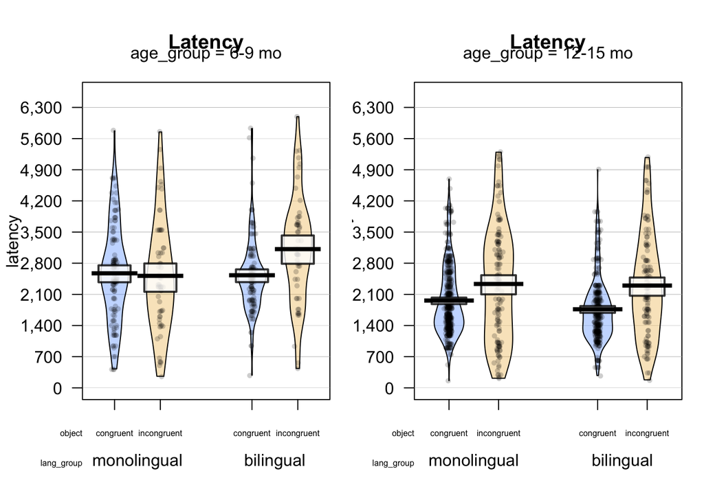

```r
pirateplot(formula = latency ~ object + lang_group + age_group, data = d_latency_meta, main = "Latency", theme = 6, pal = "southpark", cex.names = .5)
```

First graph where we see something that looks like a potential language-group difference - bilingual (younger) infants may be slower to look at incongruent objects. However - I just realized that the RR says we will only look at congruent first-looks.

## 6.3 Latency LMEM

```r
latency_lmer <- d_latency %>%
  mutate(age_days = scale(age_days, scale = FALSE)) %>%
  filter(object == "congruent") %>%
  lmer(latency ~ lang_group * age_days + (1|subid) + (lang_group | lab) + (lang_group | trial_num),
  data = .
)

summary(latency_lmer)
```

```
## Linear mixed model fit by REML. t-tests use Satterthwaite's method [
## lmerModLmerTest]
## Formula: latency ~ lang_group * age_days + (1 | subid) + (lang_group |
##     lab) + (lang_group | trial_num)
##    Data: .
##
## REML criterion at convergence: 1993.5
##
## Scaled residuals:
##     Min      1Q  Median      3Q     Max
## -5.2297 -0.4410  0.0033  0.5341  2.3158
##
## Random effects:
##  Groups    Name                Variance Std.Dev. Corr
##  subid     (Intercept)         0.055422 0.23542
##  lab       (Intercept)         0.012043 0.10974
##            lang_groupbilingual 0.013730 0.11717  -1.00
##  trial_num (Intercept)         0.008754 0.09356
##            lang_groupbilingual 0.003592 0.05994  -1.00
##  Residual                      0.367134 0.60592
## Number of obs: 996, groups:  subid, 321; lab, 9; trial_num, 6
##
## Fixed effects:
##                                Estimate Std. Error         df t value
## (Intercept)                   7.481e+00  6.331e-02  7.902e+00 118.169
## lang_groupbilingual          -8.456e-02  6.797e-02  6.226e+00  -1.244
## age_days                     -1.579e-03  4.241e-04  2.866e+02  -3.722
## lang_groupbilingual:age_days -6.659e-04  6.121e-04  1.926e+02  -1.088
##                              Pr(>|t|)
## (Intercept)                  4.05e-14 ***
## lang_groupbilingual          0.258301
## age_days                     0.000238 ***
## lang_groupbilingual:age_days 0.277998
## ---
## Signif. codes:  0 '***' 0.001 '**' 0.01 '*' 0.05 '.' 0.1 ' ' 1
##
## Correlation of Fixed Effects:
##             (Intr) lng_gr ag_dys
## lng_grpblng -0.832
## age_days    -0.032  0.029
## lng_grpbl:_  0.022  0.000 -0.698
## convergence code: 0
## singular fit
```

of course this won’t converge

## 6.4 Meta-analysis

```r
#d_z_latency <- d_latency_meta %>%
#  group_by(lab, age_group, lang_group) %>%
#  summarise(d = mean(prop, na.rm = TRUE) / sd(prop, na.rm = TRUE),
#            n = length(unique(subid)),
#            d_var = d_var_calc(n, d)) %>%
#  filter(n >= 10) #Filtering out subgroups with fewer than 10 babies

#I'm not sure how this is working - d_latency and d_latency_meta are the same dfs right now, which #seems off

#playing around
test <-
d %>%
  filter(first_shift == "congruent") %>%
  group_by(lab, age_group, lang_group, subid) %>%
  summarise(latency = mean(latency)) %>%
  group_by(lab, age_group, lang_group) %>%
  summarise(meanL = mean(latency),
         sd = sd(latency))
#I guess what we want then is a d value for the between subject comparisons of age-groupXlanguage-group per lab?
```